# InCarta Single Target Plotting

Ryan Wallis

24/05/2024

## Introduction to Single Target Analysis in R

These are some basic scripts for generating plots from InCarta Single Target files.

We reccomend going through the basic R scripts in the facility Teams Hub as well.

In this example we have two cancer cell lines MB231 and SKMEL which have been treated with a single dose of either control (DMSO) or treatment (Palbociclib)

[figure not shown]

**This is the plate layout.**

## These scripts cover:

1. Data import into R from InCarta
2. Adding data labels and filtering
3. Making basic historgrams
4. Making smooth density estimate plots
5. Making percentage frequency distributions

As with most things in R - there are more ways than this to achieve similar results but this should be a good template for using your own files.

Often the data-wrangling steps are the most complicated and it is important to make sure you are selecting the columns you need as you go through.

## Data Wrangling

```r
# Useful Packages
library("gplots")       # Graphical plots
library("RColorBrewer") # Color palettes
library("matrixStats")  # Efficient matrix computations
library("plyr")        # Data manipulation
library("dplyr")       # Data manipulation
library("data.table")  # High-performance data manipulation
library("stringr")     # String manipulation
library("ggplot2")     # Elegant plots
library("Rtsne")       # Dimensionality reduction
library("readxl")      # Read Excel files

# Import CSV File
Data <- fread("Single Target Data.csv") # Fast CSV reading using fread function  - update with your file name

# List the variables you want to keep - make sure wavelength is correct!
Variable_Names <- c("Row", "Column", "Nuclei Area wv1", "Cells Area wv2")

# Use your variables list to select the columns
Data_Tidy <- Data %>%
  select(all_of(Variable_Names))

# Add some meaningful labels based on columns - here DMSO are in columns 1-6 and Palbociclib in columns 7-12
Data_Labelled <- Data_Tidy %>%
  mutate(Treatment = case_when(Column %in% c(1:6) ~ "DMSO",
                               Column %in% c(7:12) ~ "Palbo"))

# Add some meaningful labels based on columns - here DMSO are in columns 1-6 and Palbociclib in columns 7-12
Data_Labelled <- Data_Labelled %>%
  mutate(Cells = case_when(Row %in% c("A","B","C","D") ~ "MB231",
                           Row %in% c("E","F","G","H") ~ "SKMEL"))

#Filter and Split Data As Needed
Data_MB231 <- Data_Labelled %>%
  filter(Cells == "MB231")

Data_SKMEL <- Data_Labelled %>%
  filter(Cells == "SKMEL")
```

## Making and Saving a Histogram

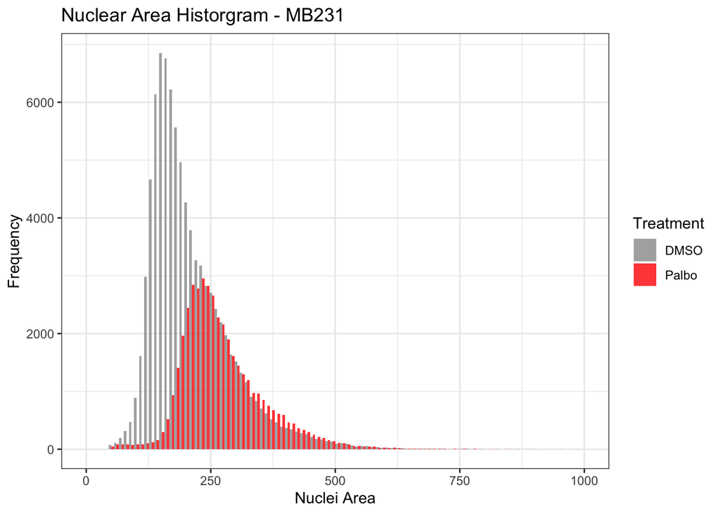

```r
# Histogram with frequency distribution
ggplot(Data_MB231, aes(x = `Nuclei Area wv1`, fill = Treatment)) +
  geom_histogram(position = "dodge", alpha = 0.8, bins = 100) +
  theme_bw() +
  scale_fill_manual(values = c("#999999", "red")) +
  labs(title = "Nuclear Area Historgram - MB231", x = "Nuclei Area", y = "Frequency") +
  guides(fill = guide_legend()) + xlim (0,1000)
```

```r
ggsave("Nuclear Area Historgram MB231.png", plot = last_plot(), width = 6, height = 4, dpi = 300)
```

## Making smooth density estimate plots

The geom_density function in ggplot2 is used to create a smoothed density estimate plot, which shows the distribution of a continuous variable. Unlike a histogram that displays counts or frequencies in discrete bins, a density plot provides a continuous curve that represents the data distribution - it can be thought of as a smoothened histogram. This often makes it easier to identify patterns and trends in the data.

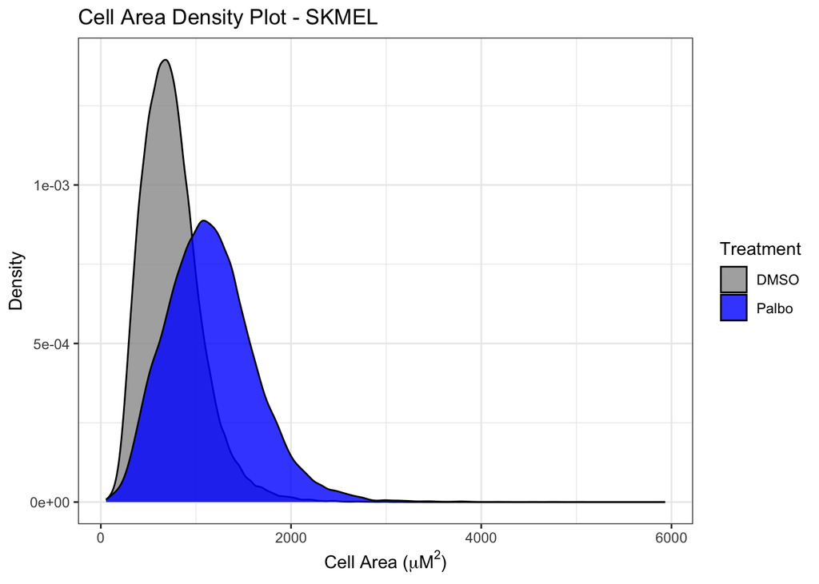

```r
# Density plot
ggplot(Data_SKMEL, aes(x = `Cells Area wv2`, fill = Treatment)) +
  geom_density(alpha = 0.8) +
  theme_bw() +
  scale_fill_manual(values = c("#999999", "blue")) +
  labs(title = "Cell Area Density Plot - SKMEL", x = expression("Cell Area (" * mu * "M"^"2" * ")"), y = "Density") +
  guides(fill = guide_legend())
```

```r
ggsave("Cell Area - SKMEL Historgram MB231.png", plot = last_plot(), width = 6, height = 4, dpi = 300)
```

## Making a Percentage Frequency Distribution

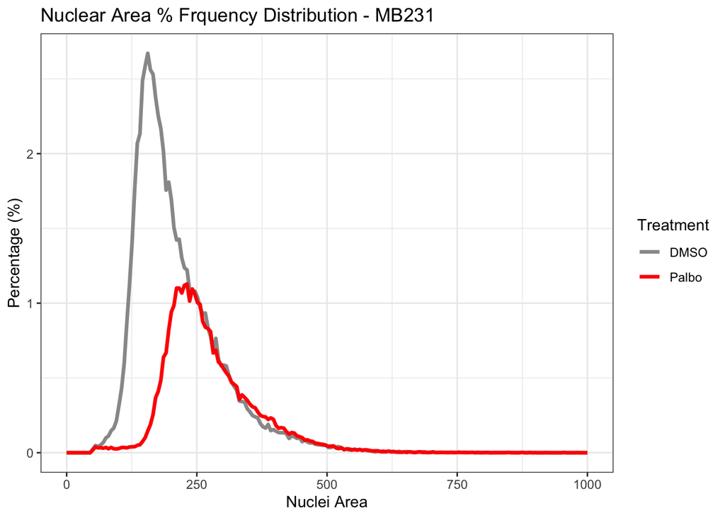

```r
# Plotting the percentage frequency polygon
ggplot(Data_MB231, aes(x = `Nuclei Area wv1`, colour = Treatment)) +
  geom_freqpoly(aes(y = ..count../sum(..count..)*100), bins = 200, size = 1.2) +
  theme_bw() +
  scale_color_manual(values = c("#999999", "red")) +
  labs(title = "Nuclear Area % Frquency Distribution - MB231", x = "Nuclei Area", y = "Percentage (%)") +
  guides(color = guide_legend()) + xlim (0,1000)
```

```r
ggsave("Nuclear Area % Frequency Distribution MB231.png", plot = last_plot(), width = 6, height = 4, dpi = 300)
```